# Precio de la vivienda en Boston

David Moreno, Santiago Amado, Yodid Cardenas

Maestría en Ciencia de Datos

Modelos Estadísticos Aplicados

6/Oct/2024

## Variables del conjunto de datos.

| Variable | Descripción |
| --- | --- |
| CRIM | Tasa de delincuencia per cápita por zona |
| ZN | Proporción de suelo residencial dividido en zonas (lotes de más de 25,000 pies cuadrados) |
| INDUS | Proporción de acres comerciales no minoristas por zona |
| CHAS | Limitaciones con el río Charles (1 si el tramo limita con el río, 0 en caso contrario) |
| NOX | Concentración de óxidos nítricos (partes por millón) |
| RM | Número medio de habitaciones por vivienda |
| AGE | Proporción de unidades ocupadas por el propietario y construidas antes de 1940 |
| DIS | Distancias ponderadas a cinco centros de empleo de Boston |
| RAD | Índice de accesibilidad a carreteras radiales |
| TAX | Tasa de impuesto a la propiedad por $10,000 |
| PTRATIO | Proporción alumno/profesor por zona |
| LSTAT | Porcentaje de la población con menor estatus social |
| MEDV | Valor medio de las viviendas ocupadas por sus propietarios (en miles de dólares) |
| CAT.MEDV | Valor medio superior o igual a 30 mil dólares (1 si es superior, 0 en otro caso) |

## Análisis de Vivienda

### Tasa de delicuencia por valor de la vivienda

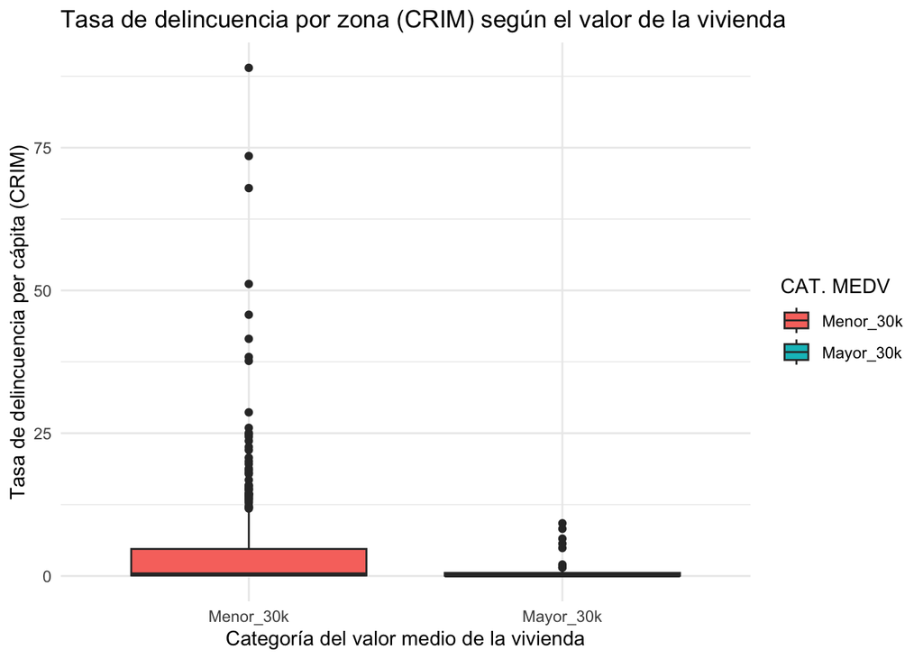

## Número Medio de Habitaciones por Valor de la Vivienda

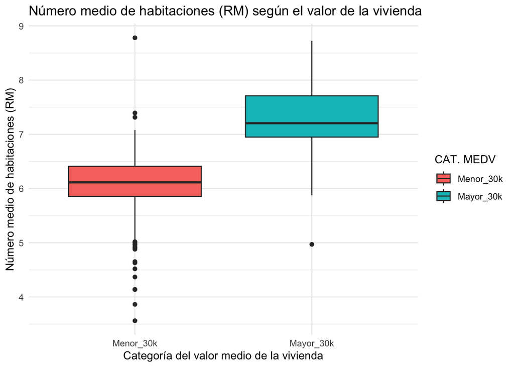

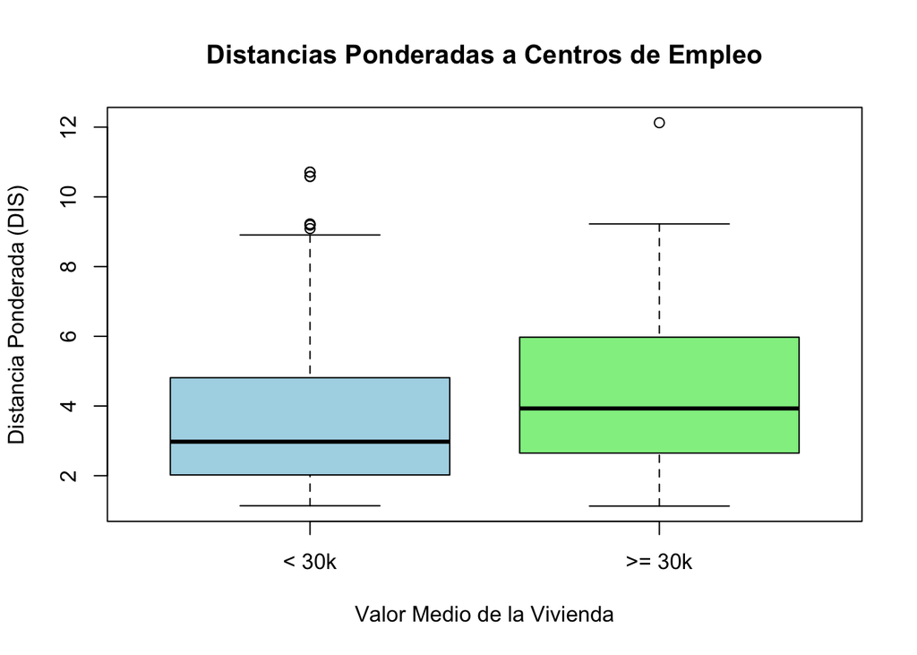

## El índice de accesibilidad a carreteras radiales.

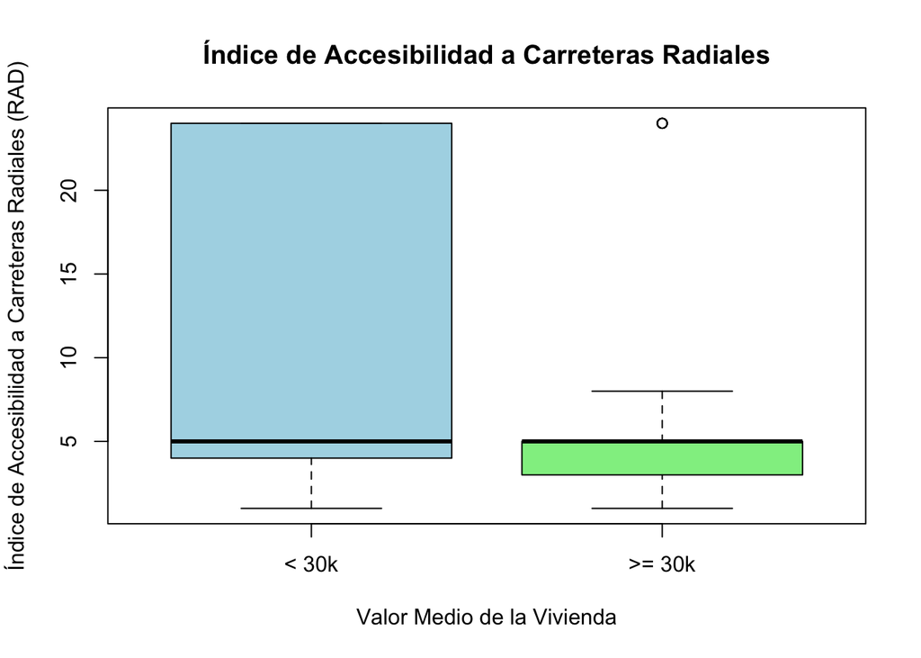

## Descripción de la hipótesis

*La hipótesis nula* es una afirmación que se asume verdadera hasta que se demuestre lo contrario. - Es el punto de partida para cualquier prueba de hipótesis y generalmente representa una situación de “no efecto” o “no diferencia”. - En el contexto del ejemplo, la hipótesis nula es: *H0:μ=71* - Esto significa que asumimos que la media de la proporción de unidades ocupadas por el propietario y construidas antes de 1940 es igual a 71.

*La hipótesis alternativa* es la afirmación que queremos probar. Representa una situación de “efecto” o “diferencia”. - En el contexto del ejemplo, la hipótesis alternativa es: *H1:μ≠71* - Esto significa que estamos probando si la media de la proporción de unidades ocupadas por el propietario y construidas antes de 1940 es diferente de 71.

*Nivel de significancia del 5%*

### Resultados de la Prueba t

```
## Resultados del análisis:
```

```
## t = -1.937956 , df = 505 , p-value = 0.05318567
```

```
## Hipótesis alternativa: la media verdadera no es igual a 71
```

```
## Intervalo de confianza del 95%:
```

```
## 66.11637 71.03343
```

```
## Estimación de la media de x:
```

```
## 68.5749
```

### Interpretación del Resultado de la Prueba t (1/3)

**Estadístico t** (t = -1.938):

Este valor indica cuántas desviaciones estándar está la media de la muestra del valor hipotético de la media (71). Un valor t negativo sugiere que la media de la muestra es menor que 71.

**Grados de libertad** (df = 505):

Los grados de libertad están relacionados con el tamaño de la muestra y afectan la forma de la distribución t. En este caso, tienes 506 observaciones (n-1).

**Valor p** (p-value = 0.05319):

El valor p indica la probabilidad de obtener un resultado tan extremo como el observado, bajo la suposición de que la hipótesis nula es verdadera.

### Interpretación del Resultado de la Prueba t (2/3)

• Si el valor p < 0.05, rechazas la hipótesis nula.  
• Si el valor p ≥ 0.05, no rechazas la hipótesis nula.

En este caso, el valor p es 0.05319, que es ligeramente mayor que 0.05. Por lo tanto, no se rechaza la hipótesis nula. No se tiene suficiente evidencia para afirmar que la media de la proporción de unidades ocupadas por el propietario y construidas antes de 1940 es diferente de 71.

*Intervalo de confianza* (95%: 66.11637, 71.03343):

Este intervalo proporciona un rango dentro del cual se espera que se encuentre la verdadera media de la población con un 95% de confianza.  
Dado que 71 está dentro de este intervalo, esto respalda la decisión de no rechazar la hipótesis nula.

### Interpretación del Resultado de la Prueba t (3/3)

*Media de la muestra* (mean of x = 68.5749):

La media de los datos de la muestra es aproximadamente 68.57.

*Conclusión:*

Dado que el valor p es ligeramente mayor que 0.05 y el intervalo de confianza incluye 71, no se tiene suficiente evidencia para rechazar la hipótesis nula. Esto significa que no se puedes concluir que la media de la proporción de unidades ocupadas por el propietario y construidas antes de 1940 sea diferente de 71.

## Predicciones

```
##       CRIM                ZN             INDUS            NOX
##  Min.   : 0.00632   Min.   :  0.00   Min.   : 0.46   Min.   :0.3850
##  1st Qu.: 0.08205   1st Qu.:  0.00   1st Qu.: 5.19   1st Qu.:0.4490
##  Median : 0.25651   Median :  0.00   Median : 9.69   Median :0.5380
##  Mean   : 3.61352   Mean   : 11.36   Mean   :11.14   Mean   :0.5547
##  3rd Qu.: 3.67708   3rd Qu.: 12.50   3rd Qu.:18.10   3rd Qu.:0.6240
##  Max.   :88.97620   Max.   :100.00   Max.   :27.74   Max.   :0.8710
##        RM             AGE              DIS              RAD
##  Min.   :3.561   Min.   :  2.90   Min.   : 1.130   Min.   : 1.000
##  1st Qu.:5.886   1st Qu.: 45.02   1st Qu.: 2.100   1st Qu.: 4.000
##  Median :6.208   Median : 77.50   Median : 3.207   Median : 5.000
##  Mean   :6.285   Mean   : 68.57   Mean   : 3.795   Mean   : 9.549
##  3rd Qu.:6.623   3rd Qu.: 94.08   3rd Qu.: 5.188   3rd Qu.:24.000
##  Max.   :8.780   Max.   :100.00   Max.   :12.127   Max.   :24.000
##       TAX           PTRATIO          LSTAT            MEDV
##  Min.   :187.0   Min.   :12.60   Min.   : 1.73   Min.   : 5.00
##  1st Qu.:279.0   1st Qu.:17.40   1st Qu.: 6.95   1st Qu.:17.02
##  Median :330.0   Median :19.05   Median :11.36   Median :21.20
##  Mean   :408.2   Mean   :18.46   Mean   :12.65   Mean   :22.53
##  3rd Qu.:666.0   3rd Qu.:20.20   3rd Qu.:16.95   3rd Qu.:25.00
##  Max.   :711.0   Max.   :22.00   Max.   :37.97   Max.   :50.00
```

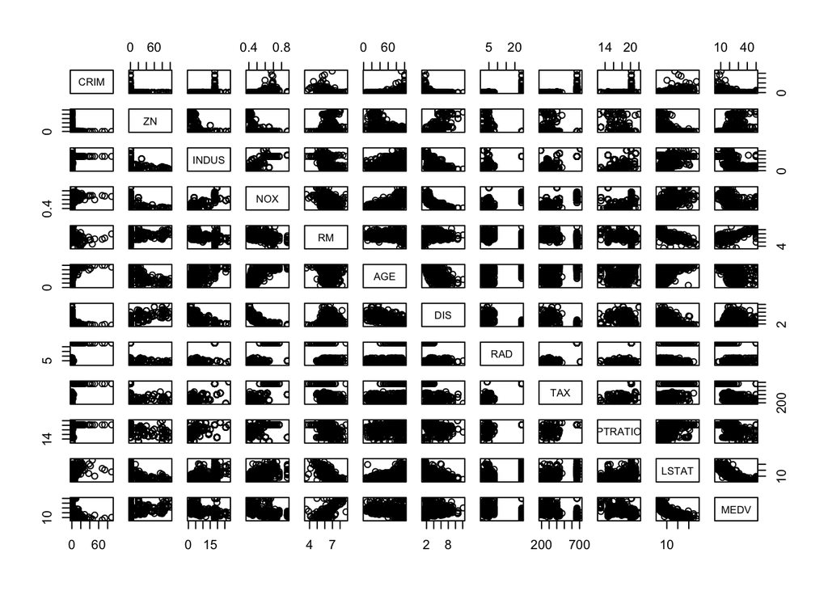

```
##
## Call:
## lm(formula = MEDV ~ ., data = boston_data_numeric)
##
## Residuals:
##      Min       1Q   Median       3Q      Max
## -12.7785  -2.8017  -0.6185   2.0915  26.5619
##
## Coefficients:
##               Estimate Std. Error t value Pr(>|t|)
## (Intercept)  42.327911   4.979197   8.501 2.24e-16 ***
## CRIM         -0.127477   0.033268  -3.832 0.000144 ***
## ZN            0.047660   0.014012   3.401 0.000725 ***
## INDUS         0.034056   0.062425   0.546 0.585627
## NOX         -18.382995   3.887082  -4.729 2.94e-06 ***
## RM            3.693754   0.424190   8.708  < 2e-16 ***
## AGE           0.005970   0.013439   0.444 0.657070
## DIS          -1.501890   0.203555  -7.378 6.83e-13 ***
## RAD           0.312184   0.067190   4.646 4.34e-06 ***
## TAX          -0.014205   0.003809  -3.729 0.000214 ***
## PTRATIO      -0.977286   0.132925  -7.352 8.15e-13 ***
## LSTAT        -0.563314   0.051032 -11.038  < 2e-16 ***
## ---
## Signif. codes:  0 '***' 0.001 '**' 0.01 '*' 0.05 '.' 0.1 ' ' 1
##
## Residual standard error: 4.845 on 494 degrees of freedom
## Multiple R-squared:  0.7286, Adjusted R-squared:  0.7225
## F-statistic: 120.5 on 11 and 494 DF,  p-value: < 2.2e-16
```

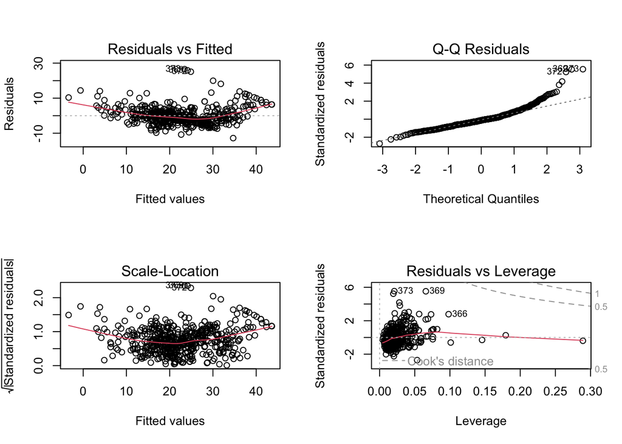

```
##        1        2
## 30.24426 25.29248
```

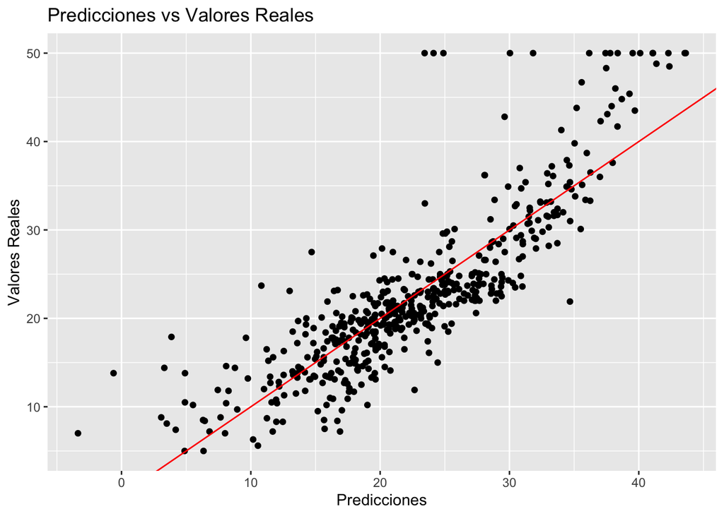

## Datos no significativos

```
##
## Call:
## lm(formula = Boston$medv ~ . - Boston$medv, data = Boston)
##
## Residuals:
##     Min      1Q  Median      3Q     Max
## -15.595  -2.730  -0.518   1.777  26.199
##
## Coefficients:
##               Estimate Std. Error t value Pr(>|t|)
## (Intercept)  3.646e+01  5.103e+00   7.144 3.28e-12 ***
## crim        -1.080e-01  3.286e-02  -3.287 0.001087 **
## zn           4.642e-02  1.373e-02   3.382 0.000778 ***
## indus        2.056e-02  6.150e-02   0.334 0.738288
## chas         2.687e+00  8.616e-01   3.118 0.001925 **
## nox         -1.777e+01  3.820e+00  -4.651 4.25e-06 ***
## rm           3.810e+00  4.179e-01   9.116  < 2e-16 ***
## age          6.922e-04  1.321e-02   0.052 0.958229
## dis         -1.476e+00  1.995e-01  -7.398 6.01e-13 ***
## rad          3.060e-01  6.635e-02   4.613 5.07e-06 ***
## tax         -1.233e-02  3.760e-03  -3.280 0.001112 **
## ptratio     -9.527e-01  1.308e-01  -7.283 1.31e-12 ***
## black        9.312e-03  2.686e-03   3.467 0.000573 ***
## lstat       -5.248e-01  5.072e-02 -10.347  < 2e-16 ***
## ---
## Signif. codes:  0 '***' 0.001 '**' 0.01 '*' 0.05 '.' 0.1 ' ' 1
##
## Residual standard error: 4.745 on 492 degrees of freedom
## Multiple R-squared:  0.7406, Adjusted R-squared:  0.7338
## F-statistic: 108.1 on 13 and 492 DF,  p-value: < 2.2e-16
```

## Datos no significativos

Dentro del análisis anterior mostrado, no son significativos las variables indus (proporción de acres comerciales no minoristas de la zona y la variable age(proporción de unidades ocupadas por el propietario y construidas antes de 1940).

Los predictores que tienen un efecto negativo sobre el precio de la vivienda son aquellos que tienen un coeficiente negativo como:

1- CRIM: Tasa de delincuencia per cápita por zona.

2- NOX: Concentración de óxido nítrico (partes por millón).

3- DIS: Distancias ponderadas a cinco centros de empleo de Boston.

4- TAX: Tasa de impuesto a la propiedad.

5- PTRATIO: Proporción alumno/profesor por zona.

6- LSTAT: Porcentaje de la población con menor estatus social.

## Punto 8.

```
##
## Call:
## lm(formula = medv ~ crim + zn + chas + nox + rm + dis + rad +
##     tax + ptratio + lstat, data = Boston)
##
## Residuals:
##      Min       1Q   Median       3Q      Max
## -15.1814  -2.7625  -0.6243   1.8448  26.3920
##
## Coefficients:
##               Estimate Std. Error t value Pr(>|t|)
## (Intercept)  41.451747   4.903283   8.454 3.18e-16 ***
## crim         -0.121665   0.032919  -3.696 0.000244 ***
## zn            0.046191   0.013673   3.378 0.000787 ***
## chas          2.871873   0.862591   3.329 0.000935 ***
## nox         -18.262427   3.565247  -5.122 4.33e-07 ***
## rm            3.672957   0.409127   8.978  < 2e-16 ***
## dis          -1.515951   0.187675  -8.078 5.08e-15 ***
## rad           0.283932   0.063945   4.440 1.11e-05 ***
## tax          -0.012292   0.003407  -3.608 0.000340 ***
## ptratio      -0.930961   0.130423  -7.138 3.39e-12 ***
## lstat        -0.546509   0.047442 -11.519  < 2e-16 ***
## ---
## Signif. codes:  0 '***' 0.001 '**' 0.01 '*' 0.05 '.' 0.1 ' ' 1
##
## Residual standard error: 4.789 on 495 degrees of freedom
## Multiple R-squared:  0.7342, Adjusted R-squared:  0.7289
## F-statistic: 136.8 on 10 and 495 DF,  p-value: < 2.2e-16
```

```
##  [1] "(Intercept)" "crim"        "zn"          "chas"        "nox"
##  [6] "rm"          "dis"         "rad"         "tax"         "ptratio"
## [11] "lstat"
```

### Usar la función predict para pronosticcar el valor medio de un inmueble con las siguientes características:

**CRIM=0.0064, ZN=12, INDUS=2.34, CHAS=0, NOX=0.538, RM=6.575, AGE=70, DIS=4.09, RAD=1, TAX=297, PTRATIO=16.3, LSTAT=4.98**

```
##       1
## 28.8666
```

```
##       fit      lwr      upr
## 1 28.8666 19.41635 38.31686
```

## Conclusiones

**1. Impacto de los predictores significativos:**

Las variables seleccionadas en el modelo final tienen un impacto significativo en el precio medio de la vivienda. Cada uno de estas variables afectan de manera importante el valor del inmueble, bien sea de forma positiva o negativa. El número de habitaciones promedio tiene un efecto positivo, mientras que variables como el índice de delincuencia (crim), la concentración de óxido nítrico, las distancias a centros de empleo, la tasa de impuesto a la propiedad, la proporción de alumnos por profesor en la zona o el porcentaje de población de clase baja tienen un impacto negativo.

**2. Precisión del pronóstico con intervalo de predicción:**

Al realizar el pronóstico para un nuevo inmueble, el modelo proporciona no solo un valor estimado, sino también un intervalo de predicción al 95%. Esto permite evaluar la confiabilidad de la predicción. El intervalo de predicción proporciona un rango donde podría caer el precio estimado con una alta probabilidad. Este enfoque añade robustez a la toma de decisiones.

El modelo es capaz de identificar los factores que más influyen en el precio de las viviendas y, a través del intervalo de predicción, proveer un marco de incertidumbre razonable sobre el valor estimado de un inmueble.

**3. Para el caso bajo estudio con los parámetros dados se estima que el valor de la vivienda con una tasa de crimen menor al 1% y una distancia de 4.09 millas a los centros de trabajo, entre otras variables, nos cuenta que esta entre 19416,35 con un máximo de 38316,86 y un valor medio de 28866,6 dólares**

## Referencias.

- U.S. Census Bureau. *Boston Housing Dataset*. Recuperado de https://www.census.gov/data.html